# Team.Rmd

Julai Lundstrum and Zack Larson

## Lab 5

#### Are there some days of the week where more accidents happen than the others (see FARS manual, use variable DAY_WEEK)?

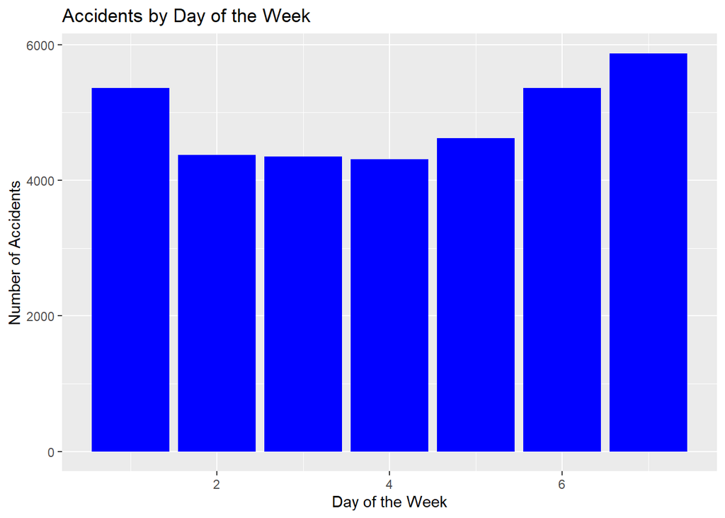

```r
ggplot(acc, aes(x = DAY_WEEK)) + geom_bar(fill = "blue") + ggtitle('Accidents by Day of the Week') +
  ylab('Number of Accidents') + xlab('Day of the Week')
```

It appears that there are more accidents on the weekends than during the week. The maximum is on Saturday with nearly 6000 accidents on Saturday. Wednesday has the least accidents with Monday and Tuesday being very close.

#### Create a data frame containing the persons who are fatally hurt in the accidents (look up variable INJ_SEV)

```r
fata <- per %>%
  filter(INJ_SEV==4)
```

#### Create a data frame containing the most dangerous vehicle make in each state. The number of persons fatally hit in the vehicle make is used to assess the (non-)safety of a make. Make sure to handle the missing values appropriately. (look up variable MAKE)

```r
dmake <- subset(fata, !is.na(`MAKE`)) %>%
  group_by(STATE) %>%
  count(MAKE, sort = TRUE) %>%
  top_n(1)
```

#### Create a map, and label each state with the most dangerous vehicle. Discuss the definition of the most dangerous vehicle, and what you find from the map. (Hint: Read the description for the STATE and COUNTY columns in the FARS manual. The state & county codes are Geographic Locator Codes (GLCs) from the General Services Administration’s (GSA) publication. Use readxl::read_xlsx to read in the GLCs.)

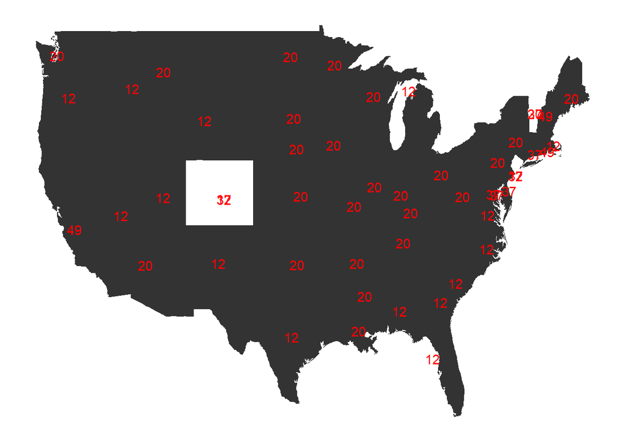

```r
states <- map_data("state")

#The state and state code are the same in both dfs and then we added the state name column after the region column in the second df
dangmap <- dmake %>%
  inner_join(geo, by = c("STATE" = "State Code")) %>%
  select(STATE, MAKE, "State Name") %>%
  distinct() %>%
  mutate("State Name" = tolower(`State Name`)) %>%
  inner_join(states, by = c("State Name" = "region"))

#We plotted the text labels based on the average coordinates that the accident took place so that will make it more likley to see the text the best
names <- dangmap %>%
  group_by(`State Name`, MAKE) %>%
  summarize(long=mean(long), lat=mean(lat))
ggplot(dangmap, aes(x=long, y = lat)) + geom_polygon(aes(group=group)) + geom_text(aes(label=MAKE), color='red', data=names) + theme_map()
```

The most dangerous vehicle make is being described as the vehicle make that was responsible for the most fatalities in these data sets. This fails to take into account the popularity of the vehicle make.

#### Join the accident and person table (work out which variable(s) to use)

```r
joined <- acc %>%
  inner_join(per, by = "ST_CASE")
```

#### Tally the number of accidents by day of the week (DAY_WEEK), hour of the day (HOUR) and gender (SEX). Visualize the results and explain what you find.

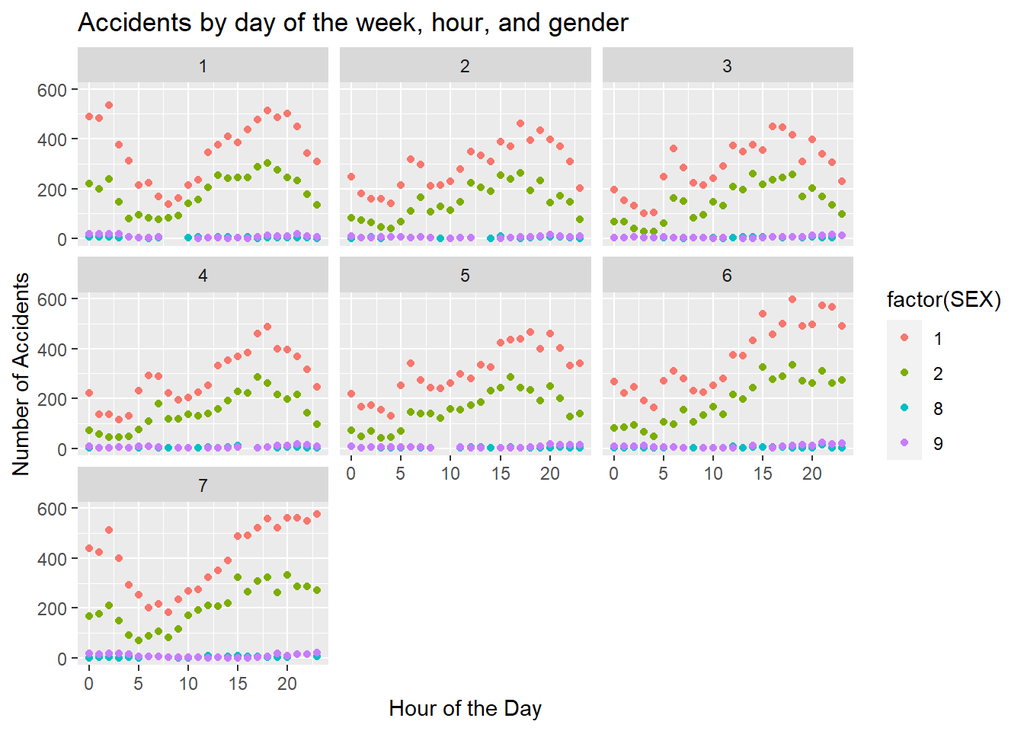

```r
#We figured it was easiest to use the hour data for the x axis, the sex for the color since there are only 2 of them, and the day of the week in a facet grid because 7 of those are more appealing than 24 if we used hour
nums <- joined %>%
  count(DAY_WEEK, HOUR.x, SEX) %>%
  filter(HOUR.x < 24)
ggplot(nums, aes(x=HOUR.x, y = n, colour = factor(SEX))) + geom_point() + facet_wrap(~ DAY_WEEK) + ggtitle("Accidents by day of the week, hour, and gender") + xlab("Hour of the Day") + ylab("Number of Accidents")
```

It appears that men are in more accidents than women. The most accidents happen between 3pm and 8pm. Accidents happen the least early in the morning.

#### Now plot a choropleth map of the number of deaths on a county level. Also explain what you find.

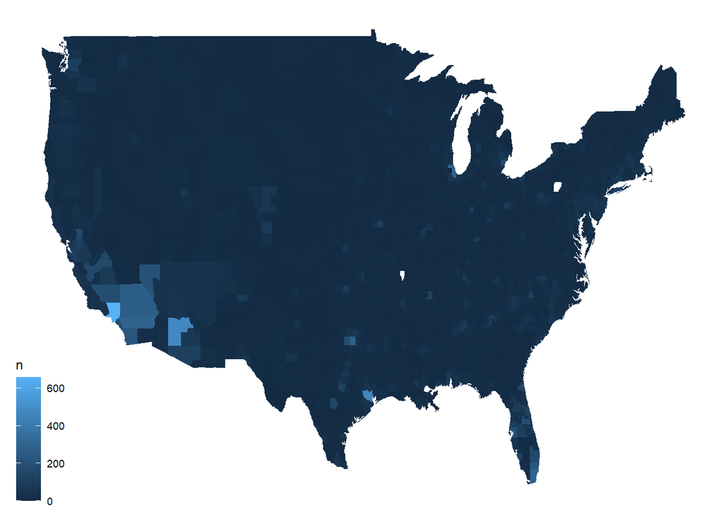

```r
#Like we did with the state data, we took the county code and COUNTY number from each data frame and joined it on that. Then we decided it would be best to also include that county name based on the subregion column
counties <- map_data("county")
cd <- fata %>%
  count(STATE, COUNTY) %>%
  right_join(geo, by = c("STATE" = "State Code", "COUNTY" = "County Code")) %>%
  select(COUNTY, STATE, n, "State Name", "County Name") %>%
  distinct()

cdmap <- cd %>%
  mutate("State Name" = tolower(`State Name`), "County Name" = tolower(`County Name`)) %>%
  right_join(counties, by = c("State Name" = "region", "County Name" = "subregion"))
cdmap[is.na(cdmap)] <- 0
ggplot(cdmap, aes(x=long, y = lat, fill = n)) + geom_polygon(aes(group=group)) + theme_map()
```

Since this map is going by totals instead of per capita, a lot of the more populated areas where cars are common stand out. Places like NYC still don’t have a lot of accidents because most people don’t own a car in NYC. California, Arizona, and Florida seem to have the most counties that have a large number of fatalities.

#### Is summer or winter more dangerous? Does this depend on states? Explore and explain.

```r
wint <- fata %>%
  filter(MONTH == c(12,1,2)) %>%
  count(STATE)
both <- fata %>%
  filter(MONTH == c(6,7,8)) %>%
  count(STATE) %>%
  full_join(wint, by= "STATE")
```

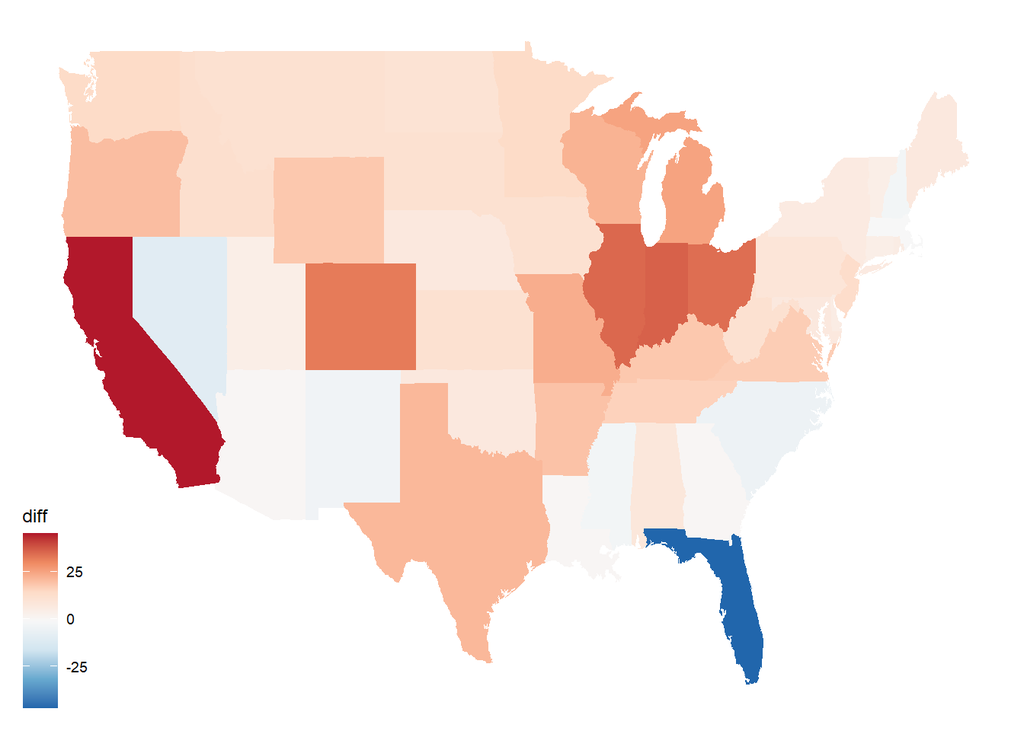

```r
both$diff <- both$n.x - both$n.y
bothmap <- both %>%
  right_join(geo, by = c("STATE" = "State Code")) %>%
  select(STATE, diff, "State Name") %>%
  distinct() %>%
  mutate("State Name" = tolower(`State Name`)) %>%
  right_join(states, by = c("State Name" = "region"))

ggplot(bothmap, aes(x=long, y = lat)) + geom_polygon(aes(group=group, fill = diff)) + theme_map() + scale_fill_distiller(palette='RdBu')
```

Overall, there are more fatalities in summer months than winter months. There are some states such as Florida that have more fatalities in the winter than the summer.